# Practice 2.2 — Canonical Cosmetic Product Classification

**Official artifact-only presentation.** This notebook never trains, creates a Test DataLoader, or repeats Final Test. E2 was frozen before the one-time Test evaluation. All displayed results are loaded read-only from the canonical lineage.

## Phase 1 - Problem Definition

Classify cosmetic product images into 10 classes using ImageNet-pretrained ResNet18. Model selection is Validation-only; Final Test is a one-time, post-freeze estimate.

## Phase 2 - Environment Setup

This setup resolves the repository paths and loads persisted canonical artifacts. It performs no training and does not construct a Test DataLoader.

```python
import json
from pathlib import Path

import matplotlib.pyplot as plt
import pandas as pd
from IPython.display import Image, Markdown, display

cwd = Path.cwd().resolve()
candidates = [cwd, *cwd.parents]
repo_root = next((p for p in candidates if (p / "total_practice" / "practice_2_2").exists()), None)
if repo_root is None:
    raise FileNotFoundError("Open this notebook from the repository containing total_practice/practice_2_2")

data_root = repo_root / "total_practice" / "practice_2_2"
canonical_root = data_root / "outputs" / "practice_2_2" / "canonical_26dc4625_52aaf974_s42_v1"
split_root = data_root / "outputs" / "practice_2_2" / "canonical_split"
e3_root = data_root / "outputs" / "practice_2_2" / "canonical_26dc4625_52aaf974_s42_phase25_e3_layer4_1_v1"
e4_root = data_root / "outputs" / "practice_2_2" / "canonical_26dc4625_52aaf974_s42_phase26_e4_augmentation_v1"
final_root = canonical_root / "final_test"

required = [
    split_root / "split_manifest.csv", split_root / "split_summary.json",
    canonical_root / "config_snapshot.json", canonical_root / "training_histories.json",
    canonical_root / "validation_comparison.csv", canonical_root / "lineage_manifest.json",
    e3_root / "phase_2_5_report.json", e4_root / "phase_2_6_report.json",
    e3_root / "training_history_e3.json", e4_root / "training_history_e4.json",
    final_root / "final_selection.json", final_root / "final_test_summary.json",
    final_root / "final_test_metrics_by_class.csv", final_root / "final_test_confusion_matrix.csv",
    final_root / "final_test_lineage.json", final_root / "pre_test_verification.json",
    final_root / "FINAL_TEST_COMPLETED.json",
]
missing = [str(path) for path in required if not path.exists()]
if missing:
    raise FileNotFoundError("Canonical artifacts are missing; do not regenerate Final Test. Missing:\n" + "\n".join(missing))

manifest = pd.read_csv(split_root / "split_manifest.csv")
split_summary = json.loads((split_root / "split_summary.json").read_text())
config = json.loads((canonical_root / "config_snapshot.json").read_text())
histories = json.loads((canonical_root / "training_histories.json").read_text())
lineage = json.loads((canonical_root / "lineage_manifest.json").read_text())
e3_report = json.loads((e3_root / "phase_2_5_report.json").read_text())
e4_report = json.loads((e4_root / "phase_2_6_report.json").read_text())
e3_history = json.loads((e3_root / "training_history_e3.json").read_text())
e4_history = json.loads((e4_root / "training_history_e4.json").read_text())
selection = json.loads((final_root / "final_selection.json").read_text())
final_summary = json.loads((final_root / "final_test_summary.json").read_text())
final_lineage = json.loads((final_root / "final_test_lineage.json").read_text())
pre_test_gate = json.loads((final_root / "pre_test_verification.json").read_text())
guard = json.loads((final_root / "FINAL_TEST_COMPLETED.json").read_text())
assert guard["FINAL_TEST_COMPLETED"] and guard["final_test_evaluation_count"] == 1
assert selection["test_used_for_selection"] is False
display(Markdown("**Artifact gate: PASS — canonical files exist and Final Test completion guard is locked.**"))
```

**Artifact gate: PASS — canonical files exist and Final Test completion guard is locked.**

## Phase 3 - Data Loading

### Dataset provenance

- Source: Tiki.vn API.
- Raw images: approximately 2,922.
- Final balanced files: 3,202.
- Per-image source URLs were not retained; complete raw reconstruction is a limitation.

### Cleaning pipeline

Historical processing removed corrupt/small images, exact duplicates and low-quality content, then resized to 224×224. Balancing produced 306 generated derivatives. Canonical training excludes all generated files and quarantines 2 suspicious cross-class images.

```python
provenance_table = pd.DataFrame([
    ["Source", "Tiki.vn API"],
    ["Raw images", "2,922"],
    ["Final balanced files", "3,202"],
    ["Model-use originals", "2,894"],
    ["Offline-generated derivatives excluded", "306"],
    ["Cross-class suspicious images quarantined", "2"],
    ["Exact duplicate groups remaining", "0"],
    ["Per-image source URL retained", "No — documented limitation"],
], columns=["Data item", "Canonical value"])
display(provenance_table.style.hide(axis="index").set_caption("Dataset provenance and cleaning summary"))
```

Dataset provenance and cleaning summary

| Data item | Canonical value |
| --- | --- |
| Source | Tiki.vn API |
| Raw images | 2,922 |
| Final balanced files | 3,202 |
| Model-use originals | 2,894 |
| Offline-generated derivatives excluded | 306 |
| Cross-class suspicious images quarantined | 2 |
| Exact duplicate groups remaining | 0 |
| Per-image source URL retained | No — documented limitation |

### Canonical duplicate-aware split

```python
model_use = manifest.loc[manifest["use_for_model"]]
split_counts = model_use["split"].value_counts().reindex(["Train", "Validation", "Test"])
display(split_counts.rename("model_use_originals").to_frame())
display(pd.DataFrame({
    "dataset_fingerprint": [split_summary["dataset_fingerprint_sha256"]],
    "split_fingerprint": [split_summary["split_fingerprint_sha256"]],
    "generated_excluded": [int(manifest["is_generated"].sum())],
    "quarantine": [int(manifest["quarantined"].sum())],
}))
assert split_counts.to_dict() == {"Train": 2016, "Validation": 438, "Test": 440}
```

| split | model_use_originals |
| --- | --- |
| Train | 2016 |
| Validation | 438 |
| Test | 440 |

|  | dataset_fingerprint | split_fingerprint | generated_excluded | quarantine |
| --- | --- | --- | --- | --- |
| 0 | 26dc4625f96c7cb86bc6a4df0fbed34bc8b22fb6472ef0... | 52aaf97499ede5dd4689c2bb36dc0679fe04b8ec8139aa... | 306 | 2 |

```python
leakage_table = pd.DataFrame([
    ["Train/Validation/Test disjoint", "PASS"],
    ["Duplicate clusters do not cross splits", "PASS"],
    ["Generated families do not cross splits", "PASS"],
    ["Exact hashes do not cross splits", "PASS"],
    ["Generated derivatives used by model", "0"],
    ["Quarantined images used by model", "0"],
], columns=["Leakage control", "Status"])
display(leakage_table.style.hide(axis="index").set_caption("Canonical leakage-safety assertions"))
```

Canonical leakage-safety assertions

| Leakage control | Status |
| --- | --- |
| Train/Validation/Test disjoint | PASS |
| Duplicate clusters do not cross splits | PASS |
| Generated families do not cross splits | PASS |
| Exact hashes do not cross splits | PASS |
| Generated derivatives used by model | 0 |
| Quarantined images used by model | 0 |

## Phase 4 - Exploratory Data Analysis

| split class_name | Train | Validation | Test |
| --- | --- | --- | --- |
| body_wash | 207 | 49 | 47 |
| face_mask | 202 | 46 | 49 |
| facial_cleanser | 230 | 46 | 45 |
| lipstick | 200 | 42 | 44 |
| moisturizer | 157 | 38 | 33 |
| perfume | 199 | 44 | 44 |
| serum | 207 | 45 | 48 |
| shampoo | 194 | 41 | 39 |
| sunscreen | 223 | 47 | 48 |
| toner | 197 | 40 | 43 |

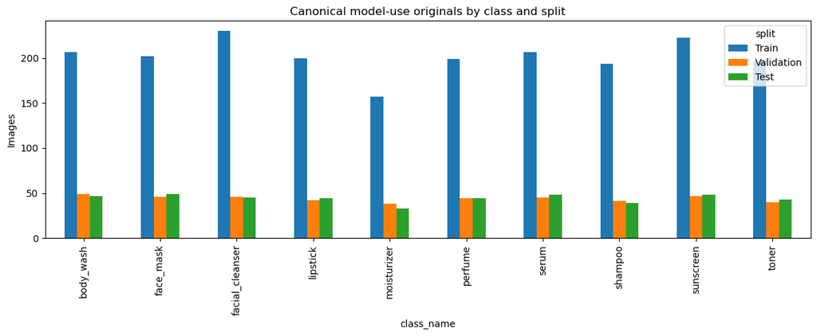

```python
class_split = pd.crosstab(model_use["class_name"], model_use["split"]).reindex(columns=["Train", "Validation", "Test"])
display(class_split)
class_split.plot(kind="bar", figsize=(12, 5), title="Canonical model-use originals by class and split")
plt.ylabel("Images")
plt.tight_layout()
plt.show()
```

## Phase 5 - Data Preprocessing

Only Train uses random augmentation. Validation and the one-time Test use deterministic Resize(256), CenterCrop(224), ToTensor and ImageNet normalization.

```python
display(Markdown("### Canonical E2 Train transform"))
print(config["train_transform"])
display(Markdown("### Deterministic Validation transform"))
print(config["validation_transform"])
```

Canonical E2 Train transform

```
Compose(
    RandomResizedCrop(size=(224, 224), scale=(0.7, 1.0), ratio=(0.75, 1.3333), interpolation=bilinear, antialias=True)
    RandomHorizontalFlip(p=0.5)
    ColorJitter(brightness=(0.8, 1.2), contrast=(0.8, 1.2), saturation=(0.8, 1.2), hue=(-0.05, 0.05))
    ToTensor()
    RandomErasing(p=0.1, scale=(0.02, 0.1), ratio=(0.5, 2.0), value=random, inplace=False)
    Normalize(mean=(0.485, 0.456, 0.406), std=(0.229, 0.224, 0.225))
)
```

Deterministic Validation transform

```
Compose(
    Resize(size=256, interpolation=bilinear, max_size=None, antialias=True)
    CenterCrop(size=(224, 224))
    ToTensor()
    Normalize(mean=(0.485, 0.456, 0.406), std=(0.229, 0.224, 0.225))
)
```

```python
transform_audit = pd.DataFrame([
    ["RandomResizedCrop", "Train only", "scale 0.70–1.00"],
    ["HorizontalFlip", "Train only", "p=0.50"],
    ["ColorJitter", "Train only", "0.20/0.20/0.20/0.05"],
    ["RandomErasing", "Train only", "p=0.10"],
    ["Resize + CenterCrop", "Validation/Test", "deterministic 256→224"],
    ["ImageNet Normalize", "All", "mean/std from pretrained weights"],
], columns=["Transform", "Applied to", "Configuration"])
display(transform_audit.style.hide(axis="index").set_caption("Preprocessing isolation"))
```

Preprocessing isolation

| Transform | Applied to | Configuration |
| --- | --- | --- |
| RandomResizedCrop | Train only | scale 0.70–1.00 |
| HorizontalFlip | Train only | p=0.50 |
| ColorJitter | Train only | 0.20/0.20/0.20/0.05 |
| RandomErasing | Train only | p=0.10 |
| Resize + CenterCrop | Validation/Test | deterministic 256→224 |
| ImageNet Normalize | All | mean/std from pretrained weights |

## Phase 6 - Model Building and Baseline

ResNet18 uses ImageNet pretrained initialization. E2 trains the full `layer4` and dropout-regularized classifier head: 8,398,858 trainable parameters out of 11,181,642.

```python
model_table = pd.DataFrame([
    ["Backbone", "ResNet18"],
    ["Initialization", "ImageNet ResNet18_Weights.DEFAULT"],
    ["Classifier", "Dropout(0.20) + Linear(512, 10)"],
    ["E1 trainable", "Classifier only — 5,130 params"],
    ["E2 trainable", "Full layer4 + classifier — 8,398,858 params"],
    ["Total parameters", "11,181,642"],
    ["Frozen BatchNorm", "eval mode; running statistics locked"],
], columns=["Architecture item", "Canonical configuration"])
display(model_table.style.hide(axis="index").set_caption("Model architecture and fine-tuning depth"))
```

Model architecture and fine-tuning depth

| Architecture item | Canonical configuration |
| --- | --- |
| Backbone | ResNet18 |
| Initialization | ImageNet ResNet18_Weights.DEFAULT |
| Classifier | Dropout(0.20) + Linear(512, 10) |
| E1 trainable | Classifier only — 5,130 params |
| E2 trainable | Full layer4 + classifier — 8,398,858 params |
| Total parameters | 11,181,642 |
| Frozen BatchNorm | eval mode; running statistics locked |

### E1 — head-only baseline

E1 reached 59.87% Train and 59.82% Validation Accuracy. The near-zero gap reflects underfitting, not superior generalization.

## Phase 7 - Model Training

### E2 — full layer4 + head

E2 reached 98.31% Train Accuracy, 78.31% Validation Accuracy and 0.7821 Validation Macro F1. It had the strongest Validation performance and was selected.

```python
training_config = pd.DataFrame([
    ["Seed", 42], ["Batch size", 32], ["Maximum epochs", 15],
    ["Optimizer", "AdamW"], ["Head LR", 0.001], ["Backbone LR", 0.0001],
    ["Weight decay", 0.0002], ["Scheduler", "ReduceLROnPlateau"],
    ["Early stopping", "val_loss, patience=3"],
    ["Best checkpoint", "Validation Accuracy"],
    ["Loss", "Class-weighted CrossEntropy + label smoothing 0.05"],
    ["Gradient clipping", 1.0],
], columns=["Training item", "Value"])
display(training_config.style.hide(axis="index").set_caption("Canonical controlled training configuration"))
```

Canonical controlled training configuration

| Training item | Value |
| --- | --- |
| Seed | 42 |
| Batch size | 32 |
| Maximum epochs | 15 |
| Optimizer | AdamW |
| Head LR | 0.001000 |
| Backbone LR | 0.000100 |
| Weight decay | 0.000200 |
| Scheduler | ReduceLROnPlateau |
| Early stopping | val_loss, patience=3 |
| Best checkpoint | Validation Accuracy |
| Loss | Class-weighted CrossEntropy + label smoothing 0.05 |
| Gradient clipping | 1.000000 |

### Training dynamics and overfitting analysis

|  | epoch | train_loss | train_acc | val_loss | val_acc | val_macro_f1 | generalization_gap | lr |
| --- | --- | --- | --- | --- | --- | --- | --- | --- |
| 0 | 1 | 1.996709 | 39.335317 | 1.422185 | 58.447489 | 0.574911 | -19.112171 | 0.001 |
| 1 | 2 | 1.141992 | 66.964286 | 1.250817 | 67.123288 | 0.661395 | -0.159002 | 0.001 |
| 2 | 3 | 0.886294 | 79.166667 | 1.236252 | 70.547945 | 0.703837 | 8.618721 | 0.001 |
| 3 | 4 | 0.716643 | 85.367063 | 1.263618 | 68.264840 | 0.686213 | 17.102223 | 0.001 |
| 4 | 5 | 0.633024 | 89.434524 | 1.171683 | 71.461187 | 0.711908 | 17.973337 | 0.001 |
| 5 | 6 | 0.563997 | 91.914683 | 1.176622 | 73.287671 | 0.734185 | 18.627011 | 0.001 |
| 6 | 7 | 0.527854 | 93.700397 | 1.151774 | 72.831050 | 0.728483 | 20.869347 | 0.001 |
| 7 | 8 | 0.493921 | 95.535714 | 1.230560 | 72.374429 | 0.723716 | 23.161285 | 0.001 |
| 8 | 9 | 0.482143 | 96.230159 | 1.144543 | 73.744292 | 0.739239 | 22.485866 | 0.001 |
| 9 | 10 | 0.459984 | 96.825397 | 1.137226 | 75.114155 | 0.749112 | 21.711242 | 0.001 |
| 10 | 11 | 0.459406 | 96.378968 | 1.063923 | 76.027397 | 0.763162 | 20.351571 | 0.001 |
| 11 | 12 | 0.454952 | 96.676587 | 1.071399 | 75.799087 | 0.759108 | 20.877501 | 0.001 |
| 12 | 13 | 0.447127 | 96.825397 | 1.107208 | 75.799087 | 0.753756 | 21.026310 | 0.001 |
| 13 | 14 | 0.416569 | 98.313492 | 1.021770 | 78.310502 | 0.782096 | 20.002990 | 0.001 |
| 14 | 15 | 0.424076 | 96.974206 | 1.087748 | 75.799087 | 0.756290 | 21.175120 | 0.001 |

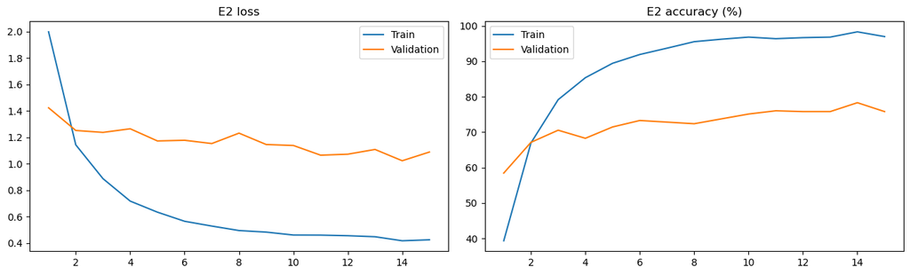

```python
e2_history = pd.DataFrame(histories["E2_partial_finetune"])
display(e2_history[["epoch", "train_loss", "train_acc", "val_loss", "val_acc", "val_macro_f1", "generalization_gap", "lr"]])
fig, axes = plt.subplots(1, 2, figsize=(13, 4))
axes[0].plot(e2_history["epoch"], e2_history["train_loss"], label="Train")
axes[0].plot(e2_history["epoch"], e2_history["val_loss"], label="Validation")
axes[0].set_title("E2 loss"); axes[0].legend()
axes[1].plot(e2_history["epoch"], e2_history["train_acc"], label="Train")
axes[1].plot(e2_history["epoch"], e2_history["val_acc"], label="Validation")
axes[1].set_title("E2 accuracy (%)"); axes[1].legend()
plt.tight_layout(); plt.show()
```

## Phase 8 - Controlled Experiments

### E3 — reduced-capacity ablation

E3 trained only `layer4.1 + head`. Validation Accuracy fell to 70.32%, showing insufficient domain adaptation. It was rejected before Test.

### E4 — augmentation ablation

E4 returned to full layer4 and used stronger online augmentation. Gap fell to 13.39 points, but Validation Accuracy fell to 72.37%. It was rejected before Test.

### Validation-only experiment comparison

```python
comparison = pd.DataFrame([
    ["E1", "Head only", 59.87, 59.82, 1.3976, 0.5975, 0.05, "Underfit"],
    ["E2", "Full layer4 + head", 98.31, 78.31, 1.0218, 0.7821, 20.00, "Selected"],
    ["E3", "layer4.1 + head", 90.08, 70.32, 1.2799, 0.7017, 19.76, "Rejected"],
    ["E4", "Stronger online augmentation", 85.76, 72.37, 1.2491, 0.7229, 13.39, "Rejected"],
], columns=["Experiment", "Strategy", "Train Acc", "Val Acc", "Val Loss", "Val Macro F1", "Gap", "Decision"])
display(comparison)
assert selection["selected_experiment_id"] == "E2_partial_finetune"
assert abs(selection["validation_accuracy"] - 78.31050228310502) < 1e-12
```

|  | Experiment | Strategy | Train Acc | Val Acc | Val Loss | Val Macro F1 | Gap | Decision |
| --- | --- | --- | --- | --- | --- | --- | --- | --- |
| 0 | E1 | Head only | 59.87 | 59.82 | 1.3976 | 0.5975 | 0.05 | Underfit |
| 1 | E2 | Full layer4 + head | 98.31 | 78.31 | 1.0218 | 0.7821 | 20.00 | Selected |
| 2 | E3 | layer4.1 + head | 90.08 | 70.32 | 1.2799 | 0.7017 | 19.76 | Rejected |
| 3 | E4 | Stronger online augmentation | 85.76 | 72.37 | 1.2491 | 0.7229 | 13.39 | Rejected |

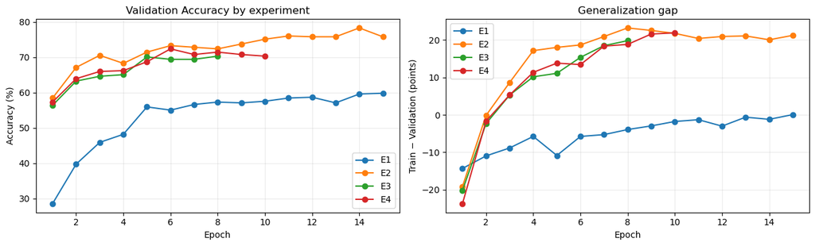

**Evidence:** E2 has the highest Validation peak; E3 loses domain adaptation and E4 lowers memorization but also lowers Validation performance.

```python
all_histories = {
    "E1": pd.DataFrame(histories["E1_head_only"]),
    "E2": pd.DataFrame(histories["E2_partial_finetune"]),
    "E3": pd.DataFrame(e3_history),
    "E4": pd.DataFrame(e4_history),
}
fig, axes = plt.subplots(1, 2, figsize=(13, 4))
for name, history in all_histories.items():
    axes[0].plot(history["epoch"], history["val_acc"], marker="o", label=name)
    axes[1].plot(history["epoch"], history["generalization_gap"], marker="o", label=name)
axes[0].set(title="Validation Accuracy by experiment", xlabel="Epoch", ylabel="Accuracy (%)")
axes[1].set(title="Generalization gap", xlabel="Epoch", ylabel="Train − Validation (points)")
for ax in axes: ax.grid(alpha=0.25); ax.legend()
plt.tight_layout(); plt.show()
display(Markdown("**Evidence:** E2 has the highest Validation peak; E3 loses domain adaptation and E4 lowers memorization but also lowers Validation performance."))
```

## Phase 9 - Model Selection and Checkpoint Verification

### Freeze canonical winner

E2 was frozen before Test using Validation Accuracy as the selection metric. E3/E4 decisions could not be revisited after Test.

```python
display(pd.Series(selection, name="frozen_selection").to_frame())
```

|  | frozen_selection |
| --- | --- |
| immutable | True |
| canonical_run_id | canonical_26dc4625_52aaf974_s42_v1 |
| selected_experiment_id | E2_partial_finetune |
| selection_metric | validation_accuracy |
| tie_breaker | validation_loss |
| best_epoch | 14 |
| validation_accuracy | 78.310502 |
| validation_macro_f1 | 0.782096 |
| checkpoint_path | /Users/vientu/Deep Learning/TOTAL_LABPARACTICE... |
| checkpoint_sha256 | 4f65bec200d023c51f95493833d057029b83a92729c3b8... |
| dataset_fingerprint_sha256 | 26dc4625f96c7cb86bc6a4df0fbed34bc8b22fb6472ef0... |
| split_fingerprint_sha256 | 52aaf97499ede5dd4689c2bb36dc0679fe04b8ec8139aa... |
| config_fingerprint_sha256 | 25a4bc76ad5f58152e5a0af3e4fa79566f2191545a060c... |
| selection_timestamp_utc | 2026-08-03T09:53:43.718211+00:00 |
| test_used_for_selection | False |
| rejected_experiments | {'E3_layer4_1_head': 'Validation performance d... |
| winner_change_allowed | False |

```python
checkpoint_table = pd.DataFrame([
    ["Selected experiment", selection["selected_experiment_id"]],
    ["Best epoch", selection["best_epoch"]],
    ["Selection metric", selection["selection_metric"]],
    ["Validation Accuracy", f'{selection["validation_accuracy"]:.4f}%'],
    ["Validation Macro F1", f'{selection["validation_macro_f1"]:.4f}'],
    ["Checkpoint SHA-256", selection["checkpoint_sha256"]],
    ["Config SHA-256", selection["config_fingerprint_sha256"]],
    ["Pre-Test verification gate", pre_test_gate["status"]],
    ["Test used for selection", selection["test_used_for_selection"]],
], columns=["Verification item", "Value"])
display(checkpoint_table.style.hide(axis="index").set_caption("Frozen winner and checkpoint identity"))
```

Frozen winner and checkpoint identity

| Verification item | Value |
| --- | --- |
| Selected experiment | E2_partial_finetune |
| Best epoch | 14 |
| Selection metric | validation_accuracy |
| Validation Accuracy | 78.3105% |
| Validation Macro F1 | 0.7821 |
| Checkpoint SHA-256 | 4f65bec200d023c51f95493833d057029b83a92729c3b88dd9159158dd949ae3 |
| Config SHA-256 | 25a4bc76ad5f58152e5a0af3e4fa79566f2191545a060c50fef9a4f9627c6c8d |
| Pre-Test verification gate | PASS |
| Test used for selection | False |

## Phase 10 - Final Test Evaluation

Final Test ran exactly once. No retraining or model reselection occurred afterward.

```python
final_table = pd.DataFrame([
    ["Test Loss", final_summary["test_loss"]],
    ["Test Accuracy (%)", final_summary["test_accuracy"]],
    ["Macro Precision", final_summary["macro_precision"]],
    ["Macro Recall", final_summary["macro_recall"]],
    ["Macro F1", final_summary["macro_f1"]],
    ["Weighted F1", final_summary["weighted_f1"]],
    ["Correct", final_summary["correct_predictions"]],
    ["Incorrect", final_summary["incorrect_predictions"]],
    ["Samples", final_summary["total_predictions"]],
], columns=["Metric", "Result"])
display(final_table)
display(Markdown(f"Validation Accuracy 78.31% vs Test Accuracy {final_summary['test_accuracy']:.2f}%: difference **{78.31050228310502-final_summary['test_accuracy']:.2f} percentage points**."))
```

|  | Metric | Result |
| --- | --- | --- |
| 0 | Test Loss | 1.018717 |
| 1 | Test Accuracy (%) | 76.363636 |
| 2 | Macro Precision | 0.765358 |
| 3 | Macro Recall | 0.765525 |
| 4 | Macro F1 | 0.761708 |
| 5 | Weighted F1 | 0.762163 |
| 6 | Correct | 336.000000 |
| 7 | Incorrect | 104.000000 |
| 8 | Samples | 440.000000 |

Validation Accuracy 78.31% vs Test Accuracy 76.36%: difference **1.95 percentage points**.

## Phase 11 - Error Analysis and Visualization

### Per-class metrics and confusion matrix

|  | class_name | precision | recall | f1 | support |
| --- | --- | --- | --- | --- | --- |
| 0 | body_wash | 0.794872 | 0.659574 | 0.720930 | 47 |
| 1 | face_mask | 0.854167 | 0.836735 | 0.845361 | 49 |
| 2 | facial_cleanser | 0.882353 | 0.666667 | 0.759494 | 45 |
| 3 | lipstick | 0.769231 | 0.909091 | 0.833333 | 44 |
| 4 | moisturizer | 0.694444 | 0.757576 | 0.724638 | 33 |
| 5 | perfume | 0.851064 | 0.909091 | 0.879121 | 44 |
| 6 | serum | 0.714286 | 0.625000 | 0.666667 | 48 |
| 7 | shampoo | 0.681818 | 0.769231 | 0.722892 | 39 |
| 8 | sunscreen | 0.666667 | 0.708333 | 0.686869 | 48 |
| 9 | toner | 0.744681 | 0.813953 | 0.777778 | 43 |

| true_class | body_wash | face_mask | facial_cleanser | lipstick | moisturizer | perfume | serum | shampoo | sunscreen | toner |
| --- | --- | --- | --- | --- | --- | --- | --- | --- | --- | --- |
| body_wash | 31 | 2 | 0 | 1 | 0 | 0 | 1 | 10 | 2 | 0 |
| face_mask | 0 | 41 | 0 | 0 | 0 | 1 | 1 | 1 | 2 | 3 |
| facial_cleanser | 3 | 2 | 30 | 2 | 3 | 1 | 2 | 0 | 2 | 0 |
| lipstick | 1 | 0 | 0 | 40 | 0 | 2 | 1 | 0 | 0 | 0 |
| moisturizer | 1 | 0 | 2 | 1 | 25 | 0 | 2 | 0 | 1 | 1 |
| perfume | 1 | 0 | 0 | 0 | 0 | 40 | 0 | 0 | 0 | 3 |
| serum | 1 | 1 | 1 | 1 | 4 | 0 | 30 | 0 | 5 | 5 |
| shampoo | 1 | 0 | 0 | 3 | 2 | 1 | 0 | 30 | 2 | 0 |
| sunscreen | 0 | 2 | 1 | 1 | 1 | 1 | 5 | 3 | 34 | 0 |
| toner | 0 | 0 | 0 | 3 | 1 | 1 | 0 | 0 | 3 | 35 |

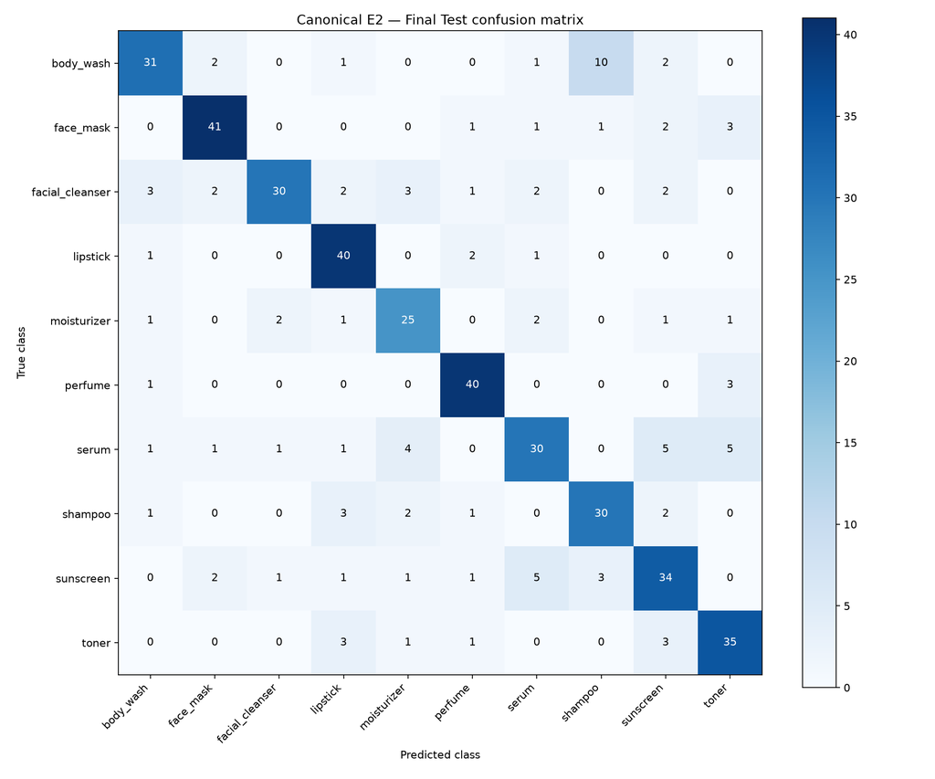

```python
per_class = pd.read_csv(final_root / "final_test_metrics_by_class.csv")
confusion = pd.read_csv(final_root / "final_test_confusion_matrix.csv", index_col=0)
display(per_class)
display(confusion)
display(Image(filename=str(final_root / "final_test_confusion_matrix.png")))
```

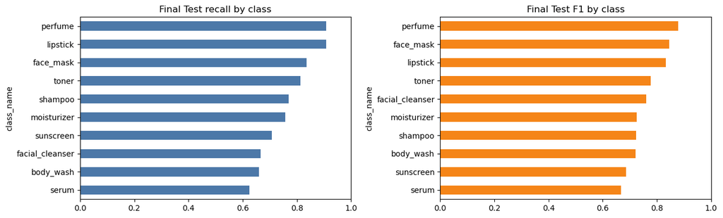

```python
fig, axes = plt.subplots(1, 2, figsize=(13, 4))
per_class.sort_values("recall").plot.barh(x="class_name", y="recall", ax=axes[0], legend=False, color="#4C78A8")
per_class.sort_values("f1").plot.barh(x="class_name", y="f1", ax=axes[1], legend=False, color="#F58518")
axes[0].set(title="Final Test recall by class", xlim=(0, 1))
axes[1].set(title="Final Test F1 by class", xlim=(0, 1))
plt.tight_layout(); plt.show()
```

### Confusion pairs and high-confidence errors

Error analysis is reporting-only and was not used for retraining or tuning.

```python
display(Markdown("### Five lowest-recall classes"))
display(pd.DataFrame(final_summary["five_lowest_recall_classes"]))
display(Markdown("### Top confusion pairs"))
display(pd.DataFrame(final_summary["top_confusion_pairs"]))
display(Markdown("### Highest-confidence errors"))
display(pd.DataFrame(final_summary["high_confidence_errors"]).head(10))
```

Five lowest-recall classes

|  | class_name | recall |
| --- | --- | --- |
| 0 | serum | 0.625000 |
| 1 | body_wash | 0.659574 |
| 2 | facial_cleanser | 0.666667 |
| 3 | sunscreen | 0.708333 |
| 4 | moisturizer | 0.757576 |

Top confusion pairs

|  | true_class | predicted_class | count |
| --- | --- | --- | --- |
| 0 | body_wash | shampoo | 10 |
| 1 | serum | sunscreen | 5 |
| 2 | serum | toner | 5 |
| 3 | sunscreen | serum | 5 |
| 4 | serum | moisturizer | 4 |
| 5 | face_mask | toner | 3 |
| 6 | facial_cleanser | body_wash | 3 |
| 7 | facial_cleanser | moisturizer | 3 |
| 8 | perfume | toner | 3 |
| 9 | shampoo | lipstick | 3 |

Highest-confidence errors

|  | stable_image_id | relative_path | true_class | predicted_class | confidence |
| --- | --- | --- | --- | --- | --- |
| 0 | 298 | body_wash/body_wash_00375.jpg | body_wash | shampoo | 0.996007 |
| 1 | 299 | body_wash/body_wash_00376.jpg | body_wash | shampoo | 0.995928 |
| 2 | 3103 | toner/toner_00282.jpg | toner | lipstick | 0.957097 |
| 3 | 1497 | moisturizer/moisturizer_00256.jpg | moisturizer | toner | 0.948929 |
| 4 | 226 | body_wash/body_wash_00276.jpg | body_wash | shampoo | 0.946888 |
| 5 | 1484 | moisturizer/moisturizer_00228.jpg | moisturizer | serum | 0.942401 |
| 6 | 225 | body_wash/body_wash_00275.jpg | body_wash | shampoo | 0.927184 |
| 7 | 1485 | moisturizer/moisturizer_00229.jpg | moisturizer | serum | 0.919537 |
| 8 | 300 | body_wash/body_wash_00377.jpg | body_wash | shampoo | 0.838409 |
| 9 | 172 | body_wash/body_wash_00201.jpg | body_wash | shampoo | 0.814203 |

## Phase 12 - Save/Load Verification, Limitations and Conclusion

### Reproducibility and save/load verification

- Canonical E2 checkpoint identity is linked by SHA-256.
- Final selection was frozen before Test.
- Model state did not change during inference.
- Final Test completion guard prevents repeated evaluation.

### Limitations

- Per-image Tiki URLs/product IDs were not persisted.
- Raw reconstruction and historical offline balancing are not fully reproducible.
- Visually overlapping packaging and some weakly informative images remain.
- Results use one canonical split and seed rather than cross-validation.
- This learning project is not production-ready.

```python
artifact_hashes = pd.DataFrame(
    list(final_lineage["output_artifact_sha256"].items()),
    columns=["Artifact", "SHA-256"],
)
display(artifact_hashes)
final_audit = pd.DataFrame([
    ["Dataset provenance", "PARTIAL", "Per-image URLs unavailable"],
    ["Cleaning pipeline", "PARTIAL", "Historical balance scripts unavailable"],
    ["Leakage protection", "PASS", "Canonical duplicate-aware split"],
    ["Training pipeline", "PASS", "Frozen config and histories"],
    ["Validation-only selection", "PASS", "E2 frozen before Test"],
    ["Final Test integrity", "PASS", "Exactly one evaluation; guard locked"],
    ["Artifact lineage", "PASS", "Hashes and canonical paths linked"],
    ["Notebook presentation", "PASS", "Artifact-only Run All"],
], columns=["Area", "Status", "Evidence"])
display(final_audit.style.hide(axis="index").set_caption("Final submission audit"))
```

|  | Artifact | SHA-256 |
| --- | --- | --- |
| 0 | final_selection.json | f532909243ba3f06f7860ca77e76a89718b5cee6fab765... |
| 1 | pre_test_verification.json | 499e9ed74c26a247ab2851cc40575b74f5346178a2036a... |
| 2 | final_test_summary.json | b346f542d600c8442571f597ce71093a9d1230a1d7fe2c... |
| 3 | final_test_metrics_by_class.csv | 75ae705579eef5858b03bc4f8e12640c83b6acde65a1c0... |
| 4 | final_test_predictions.csv | d8d18155858483b7f3bb171aa5813a5c0c79f918b1bc50... |
| 5 | final_test_confusion_matrix.csv | 42b53dd3b67774502616b8481251610db79aef17fe6443... |
| 6 | final_test_confusion_matrix.png | 8e33738cd5135672d7ffd787302f6b0668f391ef31be9c... |
| 7 | misclassified_samples.csv | 32872d88662582328c3bf6a4b20d9bc081dd2544d33a59... |
| 8 | selected_checkpoint | 4f65bec200d023c51f95493833d057029b83a92729c3b8... |
| 9 | config_snapshot | 44c8ad38c836d3cf4590f7afa9a62b244265f027209a9a... |
| 10 | canonical_manifest | aa7d6d4bb77f8ca6e7e5599ac2d49e8d55ce8192e8353f... |

Final submission audit

| Area | Status | Evidence |
| --- | --- | --- |
| Dataset provenance | PARTIAL | Per-image URLs unavailable |
| Cleaning pipeline | PARTIAL | Historical balance scripts unavailable |
| Leakage protection | PASS | Canonical duplicate-aware split |
| Training pipeline | PASS | Frozen config and histories |
| Validation-only selection | PASS | E2 frozen before Test |
| Final Test integrity | PASS | Exactly one evaluation; guard locked |
| Artifact lineage | PASS | Hashes and canonical paths linked |
| Notebook presentation | PASS | Artifact-only Run All |

### Conclusion

E2 was the best Validation-only experiment and achieved **76.36% Final Test Accuracy** and **0.7617 Macro F1** on 440 samples. Leakage controls, checkpoint identity, artifact hashes and the one-time Test guard passed. The project is internally consistent, with provenance/reconstruction limitations disclosed.